# Does a job training program improve the earnings of disadvantaged workers?

```python
# Silent warnings
import warnings
warnings.filterwarnings("ignore")

# Core
import numpy as np
import scipy
import statsmodels.api as sm
import statsmodels.formula.api as smf
import pylab

# Data
import pandas as pd
from sklearn import tree
from sklearn import metrics
from sklearn import neighbors
from sklearn import ensemble
from sklearn.neighbors import NearestNeighbors
import re
import pydotplus
from io import StringIO
from sklearn.tree import export_graphviz
from sklearn.naive_bayes import GaussianNB, MultinomialNB

# Visualisation
from IPython.display import Image, SVG
import matplotlib.pyplot as plt
import seaborn as sns

%matplotlib inline
sns.set_style('whitegrid')
plt.style.use('seaborn-whitegrid')
```

## Introduction

**Business Context.** In the 1980s, Robert Lalonde conducted a study to evaluate the effects of training programs on labour workers. He observed the characteristic background data of the individuals involved. Several of them were selected for enrollment in the job training program (the National Supported Work Demonstration). The training program specifically targeted unemployed women, ex-drug addicts, ex-criminal offenders, and high school dropouts.

[figure not shown]

The Department of Labor is interested in digging deeper into this data and coming up with some actionable insights in order to raise the earnings of disadvantaged workers. They have contracted you as a data science consultant to assist them with this task.

**Business Problem.** Your goal is to evaluate **whether the job training program *causes* the earnings of disadvantaged workers to go up**.

**Analytical Context.** In this case we will continue our discussion of causal inference. We will study the importance of covariate balance and explore how to perform matching to get this balance. We will leverage a lot of the new classification models we have learned for this purpose.

## Examining the data

The Lalonde dataset provides information on annual income for workers who enroll in the training workshop and those who did not enroll in the year subsequent to training. The outcome of interest is `re78` in which we want to know if there was an increase in earnings in 1978:

1. **age**: age in years
2. **educ**: years of schooling
3. **black**: indicator variable for blacks
4. **hisp**: indicator variable for Hispanics
5. **married**: indicator variable for martial status
6. **nodegr**: indicator variable for high school diploma
7. **re74**: real earnings in 1974
8. **re75**: real earnings in 1975
9. **re78**: real earnings in 1978 - this is the outcome of interest
10. **treat**: an indicator variable for treatment status

```python
lalonde_df = pd.read_csv('lalonde.csv', index_col=0)
lalonde_df.head()
```

|  | treat | age | educ | black | hispan | married | nodegree | re74 | re75 | re78 |
| --- | --- | --- | --- | --- | --- | --- | --- | --- | --- | --- |
| NSW1 | 1 | 37 | 11 | 1 | 0 | 1 | 1 | 0.0 | 0.0 | 9930.0460 |
| NSW2 | 1 | 22 | 9 | 0 | 1 | 0 | 1 | 0.0 | 0.0 | 3595.8940 |
| NSW3 | 1 | 30 | 12 | 1 | 0 | 0 | 0 | 0.0 | 0.0 | 24909.4500 |
| NSW4 | 1 | 27 | 11 | 1 | 0 | 0 | 1 | 0.0 | 0.0 | 7506.1460 |
| NSW5 | 1 | 33 | 8 | 1 | 0 | 0 | 1 | 0.0 | 0.0 | 289.7899 |

### Exercise 1:

#### 1.1

Provide summary statistics for all the variables in the dataset. What can you say about the average income of the population throughout the years? What percentage of the population saw a decrease in income from 1974 to 1975? What do you think happened in 1975?

**Answer.**

```python
lalonde_df.describe().T
```

|  | count | mean | std | min | 25% | 50% | 75% | max |
| --- | --- | --- | --- | --- | --- | --- | --- | --- |
| treat | 614.0 | 0.301303 | 0.459198 | 0.0 | 0.000000 | 0.0000 | 1.00000 | 1.00 |
| age | 614.0 | 27.363192 | 9.881187 | 16.0 | 20.000000 | 25.0000 | 32.00000 | 55.00 |
| educ | 614.0 | 10.268730 | 2.628325 | 0.0 | 9.000000 | 11.0000 | 12.00000 | 18.00 |
| black | 614.0 | 0.395765 | 0.489413 | 0.0 | 0.000000 | 0.0000 | 1.00000 | 1.00 |
| hispan | 614.0 | 0.117264 | 0.321997 | 0.0 | 0.000000 | 0.0000 | 0.00000 | 1.00 |
| married | 614.0 | 0.415309 | 0.493177 | 0.0 | 0.000000 | 0.0000 | 1.00000 | 1.00 |
| nodegree | 614.0 | 0.630293 | 0.483119 | 0.0 | 0.000000 | 1.0000 | 1.00000 | 1.00 |
| re74 | 614.0 | 4557.546569 | 6477.964479 | 0.0 | 0.000000 | 1042.3300 | 7888.49825 | 35040.07 |
| re75 | 614.0 | 2184.938207 | 3295.679043 | 0.0 | 0.000000 | 601.5484 | 3248.98750 | 25142.24 |
| re78 | 614.0 | 6792.834483 | 7470.730792 | 0.0 | 238.283425 | 4759.0185 | 10893.59250 | 60307.93 |

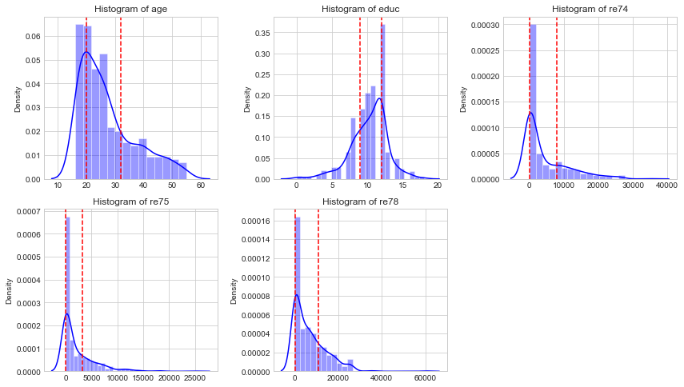

```python
fig = plt.figure(figsize=(12,10))
vars_to_look = ['treat', 'age', 'educ', 'black', 'hispan', 'married', 'nodegree', 're74', 're75', 're78']

for i, var in enumerate( [vars_to_look[i] for i in [1,2,7,8,9]] ):
    plt.subplot(3,3,i+1)
    sns.distplot(x = lalonde_df[var], color='blue')
    plt.title("Histogram of " + var)
    plt.axvline(x = np.quantile(lalonde_df[var], q=0.25), color= 'red', ls='--')
    plt.axvline(x = np.quantile(lalonde_df[var], q=0.75), color= 'red', ls='--')

fig.set_tight_layout(True)
```

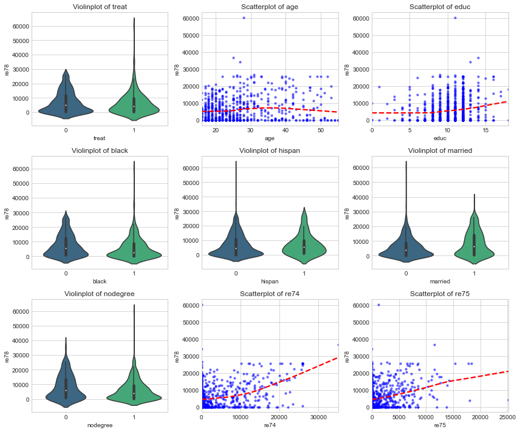

```python
fig = plt.figure(figsize=(12,10))

for i, var in enumerate( [vars_to_look[i] for i in range(0,9)] ):
    plt.subplot(3,3,i+1)
    if var in ['treat', 'black', 'hispan', 'married', 'nodegree']:
        sns.violinplot(x=lalonde_df[var], y = lalonde_df['re78'], palette='viridis',
                    boxprops={'alpha':0.5}, flierprops={'marker':'o'})
        plt.title("Violinplot of " + var)
    else:
        sns.regplot(x = lalonde_df[var], y=lalonde_df['re78'], lowess=True,
                        line_kws = {'color': "red", 'ls':'--'},
                        scatter_kws = {"s": 10, 'alpha':0.5, 'color':'blue'})
        plt.title("Scatterplot of " + var)
fig.set_tight_layout(True)
```

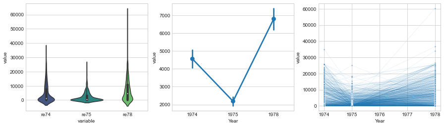

```python
lalonde_df1 = pd.melt(lalonde_df.loc[:, 're74':'re78'].reset_index(), id_vars=['index'])
fig,ax = plt.subplots(1,3, figsize=(15,4))
sns.violinplot(x='variable', y = 'value', data=lalonde_df1, palette='viridis', ax=ax[0]);
#
lalonde_df1['Year'] = lalonde_df1['variable'].map(lambda x: re.sub(r'^re', '19', x)).astype(int)
sns.pointplot(x = 'Year', y='value', data=lalonde_df1, ax=ax[1]);
#
sns.lineplot(x='Year', y = 'value', units='index', data = lalonde_df1,
             estimator=None, marker='.', linewidth=0.2, alpha=0.4, ax=ax[2]);
```

The average income in this population decreased in 1975 compared to 1974 but rose again in 1978. This is not evident in the violin graph, but it is evident in the point estimation graph. It is observed that a higher proportion of individuals had low salary levels in 1975 compared to 1974. Apparently in 1978 there was a high proportion of individuals with very high salaries.

```python
lalonde_df2 = pd.melt(lalonde_df.reset_index(),
        id_vars= ['index', 'treat', 'age', 'educ', 'black', 'hispan', 'married', 'nodegree'],
        value_vars = ['re74', 're75', 're78'])
lalonde_df2['Year'] = lalonde_df2['variable'].map(lambda x: re.sub(r'^re', '19', x)).astype(int)
```

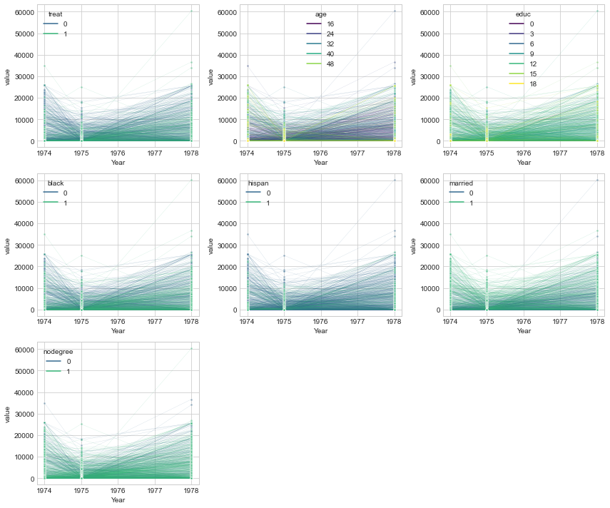

```python
fig = plt.figure(figsize=(12,10))
for i, var in enumerate( ['treat', 'age', 'educ', 'black', 'hispan', 'married', 'nodegree'] ):
    plt.subplot(3,3,i+1)
    sns.lineplot(x='Year', y = 'value', units='index', hue = var, data = lalonde_df2, palette='viridis', dashes=var,
             estimator=None, marker='.', linewidth=0.2, alpha=0.4);
#     sns.pointplot(x='Year', y = 'value', units='index', hue = var, data = lalonde_df2, palette='viridis');
fig.set_tight_layout(True);
```

Exploring the covariates for each individual, a possible relationship between them and a decrease between the years 1974 to 1975 is not found, so the cause cannot be known. Likewise, there are no historical events this year (apart from the convictions handed down by the Watergate case) that can explain the behavior.

#### 1.2

What percentage of the workers in our dataset are in the treatment group? Find the difference in means and medians of earnings between the control group and the treatment group. Is the difference of means statistically significant?

**Note:** Remember that the *treatment and control groups* correspond to the sets of workers that were enrolled and not enrolled in the job training program, respectively. We can check if a worker is part of the treatment group by simply checking the value of the `treat` column.

**Answer.**

```python
dummy = lalonde_df\
.groupby('treat')\
.agg({'re78':['count', 'mean', 'median']})

dummy.columns = dummy.columns.droplevel()
dummy['prop'] = dummy['count'] * 100 / dummy['count'].sum()
dummy
```

| treat | count | mean | median | prop |
| --- | --- | --- | --- | --- |
| 0 | 429 | 6984.169742 | 4975.505 | 69.869707 |
| 1 | 185 | 6349.143530 | 4232.309 | 30.130293 |

We have that 30.13% of the individuals in this dataset are in the intervention group.

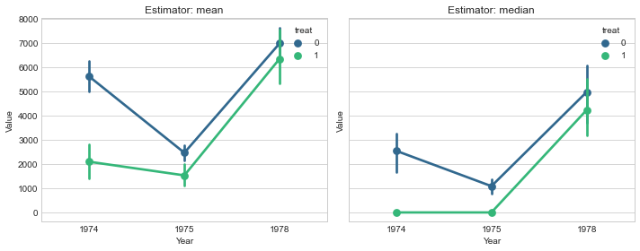

```python
fig, ax = plt.subplots(1, 2, figsize=(10, 4), sharex=True, sharey=True)
sns.pointplot(x='Year', y = 'value', hue = 'treat', data = lalonde_df2, palette='viridis', dashes='treat',
             marker='.', linewidth=0.2, alpha=0.4, ax=ax[0])
ax[0].set(title='Estimator: mean', ylabel='Value')

sns.pointplot(x='Year', y = 'value', hue = 'treat', data = lalonde_df2, palette='viridis', dashes='treat', estimator=np.median,
             marker='.', linewidth=0.2, alpha=0.4, ax=ax[1])
ax[1].set(title='Estimator: median', ylabel='Value')
fig.set_tight_layout(True);
```

#### 1.3

Does your previous result mean that the treatment had a negative impact? Why or why not?

**Answer.** As mentioned previously, both groups tend to have an equivalent average income for the year 1978, despite the initial income gap. For this reason, it can be said that the intervention had a significant impact on the workers.

## Assessing balance between the control group and the treatment group

Suppose we want to assess whether balance has been achieved for a particular feature $x = age$. That is, we would like to check whether the treatment and control groups have similar distributions of ages. We can look at **Standardized Mean Differences (SMD)**, which is calculated as follows: let $(\bar{x}_t,s_t^2)$ and $(\bar{x}_c, s_c^2)$ denote the mean and variance corresponding to the treatment and control groups of the particular feature of interest. Then, the SMD is defined as the value:
$$\mathrm{SMD}(x)=\frac{\bar{x}_{t}-{\bar{x}_{c}}}{\sqrt{\frac{s^{2}_{t} + s^{2}_{c}}{2}}}.$$
We can calculate the SMD for every feature. If our calculated SMD is 1, then that means there is a 1 standard deviation difference in means. The benefit of having standard deviation in the denominator is that this number becomes insensitive to the scale of the feature.

After computing this measurement for all of our features, there is a rule of thumb that is commonly used to determine whether that feature is balanced or not (similar to the idea of using 0.05 as a threshold for $p$ - values):

1. **SMD < 0.1**: We say that the feature is balanced. In general, for a **randomized trial**, the SMD for all of the covariates should typically fall into this bucket.
2. **SMD is between 0.1 and 0.2**: Not necessarily balanced, but small enough that people are usually not too worried about them. Sometimes, even after performing matching, there might still be a few covariates whose SMD falls in this range.
3. **SMD > 0.2**: Values that are greater than this threshold are considered seriously imbalanced.

### Exercise 2:

#### 2.1

Assess covariate balance between the treatment and control groups. What features (covariates) are imbalanced between the control group and the treatment group in this dataset?

**Answer.**

```python
def SMD(df:pd.DataFrame, treatment:str, feature:str):
    try:
        tv = df[df[treatment] == 1][feature]
        cv = df[df[treatment] == 0][feature]
    except:
        print('Treatment variable should be coded as 0 or 1')
    smd = (np.mean(tv) - np.mean(cv)) / np.sqrt((np.var(tv) + np.var(cv))/2)
    # Interpretation
    if (np.abs(smd) < 0.1):
        interpret = 'Balanced feature'
    elif (np.abs(smd) <= 0.2):
        interpret = 'Not necessarily balanced feature'
    else:
        interpret = 'Seriously imbalanced'
    #
    return([smd, interpret])
```

```python
smdTable = pd.DataFrame({'features':["age", "educ", "black", "hispan", "married", "nodegree", "re74", "re75", "re78"]})

smdTable['SMD'] = smdTable['features'].map(lambda x: round(SMD(lalonde_df, 'treat', x)[0], 2) )
smdTable['Itr'] = smdTable['features'].map(lambda x: SMD(lalonde_df, 'treat', x)[1] )
smdTable
```

|  | features | SMD | Itr |
| --- | --- | --- | --- |
| 0 | age | -0.24 | Seriously imbalanced |
| 1 | educ | 0.04 | Balanced feature |
| 2 | black | 1.67 | Seriously imbalanced |
| 3 | hispan | -0.28 | Seriously imbalanced |
| 4 | married | -0.72 | Seriously imbalanced |
| 5 | nodegree | 0.24 | Seriously imbalanced |
| 6 | re74 | -0.60 | Seriously imbalanced |
| 7 | re75 | -0.29 | Seriously imbalanced |
| 8 | re78 | -0.08 | Balanced feature |

As can be seen in the table above, most of the covariates present a significant degree of imbalance, with the exception of education and earnings in 1978.

#### 2.2

Make plots which show the histograms for both the treatment and control groups of the imbalanced covariates.

**Answer.**

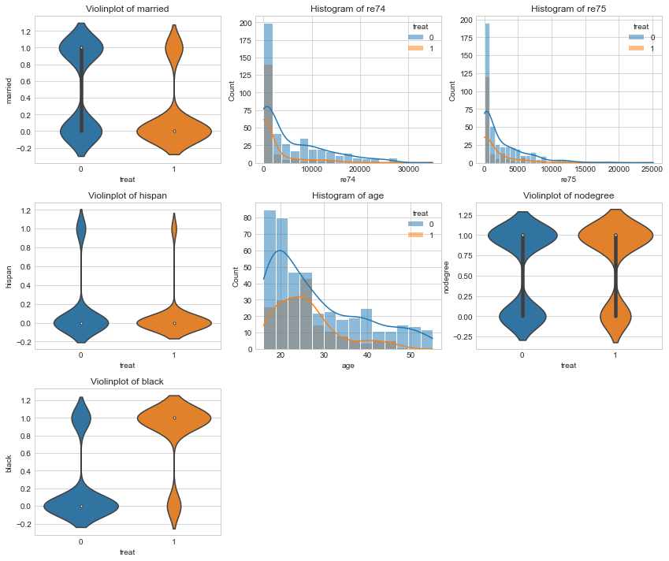

```python
fig = plt.figure(figsize=(12,10))

for i, var in enumerate( smdTable[smdTable['Itr'] == 'Seriously imbalanced'].sort_values('SMD')['features'] ):
    plt.subplot(3,3,i+1)
    if var in ['age', 're74', 're75']:
        sns.histplot(data=lalonde_df, x=var, hue='treat', kde=True)
        plt.title("Histogram of " + var)
    else:
        sns.violinplot(data=lalonde_df, x='treat', y=var)
        plt.title("Violinplot of " + var)

fig.set_tight_layout(True)
```

It's observed that the proportion of married people is lower in the intervention group, in a similar way in the intervention group individuals have lower income in years 74 and 75. Likewise, in the intervention group individuals are younger, and the proportion of Hispanics is lower.  
On the other hand, in the intervention group there is a higher proportion of people without university degrees and Afro-descendants.

## Propensity score matching using logistic regression

In order to balance the covariates of the control and treatment groups, we will use **matching**. Remember that we used matching in Case 7.5 to balance a population of prisoners to evaluate the effectiveness of a program aiming to reduce recidivism. Thus, the situation here is quite similar.

In Case 7.5 we used the *Euclidean distance* on the sample data to create the matching: for each individual of the treatment group, we would find the closest (in Euclidean distance) individual in the control group to match on. Although this method is attractive in general, we may have instances in which the balancing of some particular feature is more important than others. Say the employment program was aiming to create a positive impact within the Hispanic community and a higher proportion of individuals in the treatment group were Hispanic. The Euclidean distance would not take this into account, and we may end up comparing the effect of the treatment between Hispanics and other ethnicities.

We can alleviate this issue by using a metric that takes into account the characteristics of the treatment group. In this context, a metric called the **propensity score** helps us do the matching on select features in an efficient way. The key idea is that *the features that are correlated with the probability of a worker being selected into the treatment group affect our causal results*. A propensity score is this probability. The propensity score for subject $i$, denoted as $\pi_i$ is defined as:

$\pi_i$ = P(Subject $i$ is given training given their features $X_i$)

As an example, if a person had a propensity score of 0.3, that would mean that given their particular covariates, there was a 30% chance that they were placed in the treatment group. We can calculate this score by fitting a classification model to our data, where the input features are our covariates, and the output is whether that person was part of the treatment group or not.

### Exercise 3:

#### 3.1

Estimate the propensity scores using a logistic regression. Build a logistic regression model where the outcome variable is whether a subject was in the treatment group or not, and the covariates are all the other variables except `re78`. How would you interpret the predicted values output by the model?

**Answer.**

```python
# Create a code with categorical values instead
lalonde_df_copy = lalonde_df.copy()
lalonde_df_copy['Intercept'] = 1

covariates  = list(lalonde_df_copy.iloc[:, [1,2,3,4,5,6,7,8]].columns)

lo_mod_Full = sm.Logit(lalonde_df_copy.iloc[:, [0]], lalonde_df_copy.iloc[:, [1,2,3,4,5,6,7,8,10]]).fit()
# lo_mod_Full = sm.Logit(lalonde_df_copy['treat'], lalonde_df_copy[[j for i in [covariates, ['Intercept']] for j in i]]).fit()
lo_mod_Full.summary()
```

```
Optimization terminated successfully.
         Current function value: 0.415889
         Iterations 7
```

Logit Regression Results

| Dep. Variable: | treat | No. Observations: | 614 |
| --- | --- | --- | --- |
| Model: | Logit | Df Residuals: | 605 |
| Method: | MLE | Df Model: | 8 |
| Date: | Fri, 16 Oct 2020 | Pseudo R-squ.: | 0.3204 |
| Time: | 02:13:00 | Log-Likelihood: | -255.36 |
| converged: | True | LL-Null: | -375.75 |
| Covariance Type: | nonrobust | LLR p-value: | 1.548e-47 |

|  | coef | std err | z | P>\|z\| | [0.025 | 0.975] |
| --- | --- | --- | --- | --- | --- | --- |
| age | -0.0142 | 0.013 | -1.113 | 0.265 | -0.039 | 0.011 |
| educ | -0.1283 | 0.040 | -3.209 | 0.001 | -0.207 | -0.050 |
| black | 2.7083 | 0.334 | 8.097 | 0.000 | 2.053 | 3.364 |
| hispan | 0.5287 | 0.401 | 1.320 | 0.187 | -0.256 | 1.314 |
| married | -0.7779 | 0.306 | -2.543 | 0.011 | -1.378 | -0.178 |
| nodegree | -0.5096 | 0.258 | -1.979 | 0.048 | -1.014 | -0.005 |
| re74 | -6.176e-05 | 3.14e-05 | -1.965 | 0.049 | -0.000 | -1.49e-07 |
| re75 | 5.05e-05 | 4.48e-05 | 1.127 | 0.260 | -3.73e-05 | 0.000 |
| pscore | 0.5564 | 1.144 | 0.486 | 0.627 | -1.685 | 2.798 |

#### 3.2

Use `.predict()` to obtain the propensity scores of individuals in our dataset. Save the the results with the name `pscore_logit` (these will be used later). In addition, make plots which show the distribution for both the treatment and control groups of propensity scores.

**Answer.**

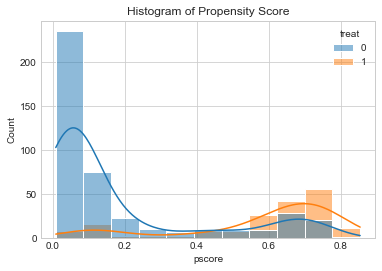

```python
pscore_logit = lo_mod_Full.predict()
pscore_df = pd.DataFrame({'treat':lalonde_df_copy['treat'], 'pscore':pscore_logit})

sns.histplot(data=pscore_df, x='pscore', hue='treat', kde=True)
plt.title("Histogram of Propensity Score");
```

### Matching using $k$-nearest neighbors

We are going to match each treated subject with a control subject using nearest neighbors matching on the estimated propensity score. Here, we use another popular clustering algorithm: the **$k$-nearest neighbors ($k$-NN) algorithm**. This algorithm is quite similar to the one we used in Case 7.5. However, instead of finding the single control individual with the closest propensity score, it finds the $k$ control individuals with the closest propensity scores. The use of $k>1$ is handy for classification purposes: if each individual lies in a category, we can classify a new individual by finding its $k$ nearest neighbors and use the most common category of its neighbors as the selected category for the new individual.

### Exercise 4 :

In this exercise, we will use the `sklearn.neighbors` function [`NearestNeighbors`](https://scikit-learn.org/stable/modules/generated/sklearn.neighbors.NearestNeighbors.html#sklearn.neighbors.NearestNeighbors.kneighbors) to find, for each subject in the treatment group, the $k=5$ subjects in the control group with the closest propensity scores.

#### 4.1

Separate the propensity scores `pscore_logit` found in Exercise 3 for treatment and control groups. Call these `treat_pscores` and `control_pscores` respectively. Use the `control_pscores` to train a $k$-NN algorithm with $k=5$.

**Hint:** Load the model using `knn = neighbors.NearestNeighbors(n_neighbors=5,metric='euclidean')`. You may want to reshape the control scores using `control_pscores.reshape(-1,1)`.

**Answer.**

```python
treat_pscores = pscore_df.query('treat == 1')['pscore']
control_pscores = pscore_df.query('treat == 0')['pscore']
```

```python
neigh = NearestNeighbors(n_neighbors=5, metric='euclidean')
neigh.fit(control_pscores.values.reshape(-1,1))
```

```
NearestNeighbors(metric='euclidean')
```

#### 4.2

Find the indices of the five nearest neighbors using the method `.kneighbors()` applied to `treat_pscores`.

**Answer.**

```python
listSimilars = []

for i, sample in enumerate(treat_pscores):
    dist, arr = neigh.kneighbors([[sample]], 5, return_distance=True)
    similars = control_pscores.iloc[arr[0]]
    listSimilars.append(similars)
```

```python
listSimilars[0:2]
```

```
[PSID69     0.638554
 PSID387    0.635754
 PSID373    0.642893
 PSID386    0.642893
 PSID376    0.646269
 Name: pscore, dtype: float64,
 PSID111    0.224079
 PSID66     0.222595
 PSID339    0.216196
 PSID150    0.212873
 PSID199    0.237886
 Name: pscore, dtype: float64]
```

#### 4.3

Match the treatment and control groups using the closest of the five neighbors found above. Your output should be a pair of `DataFrames`, each with $185$ rows from the `lalonde_df`. The first should correspond to the treatment group and the second should correspond to the matched control group.

**Answer.**

```python
lalonde_df.query('treat==1').head(5)
```

|  | treat | age | educ | black | hispan | married | nodegree | re74 | re75 | re78 |
| --- | --- | --- | --- | --- | --- | --- | --- | --- | --- | --- |
| NSW1 | 1 | 37 | 11 | 1 | 0 | 1 | 1 | 0.0 | 0.0 | 9930.0460 |
| NSW2 | 1 | 22 | 9 | 0 | 1 | 0 | 1 | 0.0 | 0.0 | 3595.8940 |
| NSW3 | 1 | 30 | 12 | 1 | 0 | 0 | 0 | 0.0 | 0.0 | 24909.4500 |
| NSW4 | 1 | 27 | 11 | 1 | 0 | 0 | 1 | 0.0 | 0.0 | 7506.1460 |
| NSW5 | 1 | 33 | 8 | 1 | 0 | 0 | 1 | 0.0 | 0.0 | 289.7899 |

```python
similar_lalonde = pd.DataFrame()

for i, sims in enumerate(listSimilars):
    matched_id = sims.index[0]
    row = lalonde_df[lalonde_df.index == matched_id]
    similar_lalonde = pd.concat([similar_lalonde, row])
```

```python
similar_lalonde.head(5)
```

|  | treat | age | educ | black | hispan | married | nodegree | re74 | re75 | re78 |
| --- | --- | --- | --- | --- | --- | --- | --- | --- | --- | --- |
| PSID69 | 0 | 30 | 17 | 1 | 0 | 0 | 0 | 17827.37000 | 5546.4190 | 14421.1300 |
| PSID111 | 0 | 51 | 11 | 0 | 0 | 0 | 1 | 48.98167 | 3813.3870 | 1525.0140 |
| PSID370 | 0 | 16 | 9 | 1 | 0 | 0 | 1 | 0.00000 | 0.0000 | 2158.9590 |
| PSID226 | 0 | 39 | 10 | 1 | 0 | 0 | 1 | 844.44400 | 889.7903 | 701.9201 |
| PSID140 | 0 | 19 | 9 | 1 | 0 | 0 | 1 | 1079.55600 | 2873.4680 | 14344.2900 |

```python
matched_lalonde = pd.concat([lalonde_df.query('treat==1'), similar_lalonde])
```

### Propensity score distribution plot after matching

Let's take a glance at the distribution of propensity score after matching. Both groups have similar distributions on the propensity score. This means we have reach a balance in both groups. This enables us to further analyze the causality effect of the treatment.

### Exercise 5 :

Make a plot which shows the histograms of propensity scores for the control and treatment groups after matching. Compare your results with the plot in Exercise 3.2.

**Answer.**

```python
# Add an intercept to make predicctions
matched_lalonde['Intercept'] = 1
# Select only columns that refer to independent variables
pscore_logit1 = lo_mod_Full.predict(
                matched_lalonde.iloc[:, [1,2,3,4,5,6,7,8,10]]
)
pscore_df1 = pd.DataFrame({'treat':matched_lalonde['treat'], 'pscore':pscore_logit1})
```

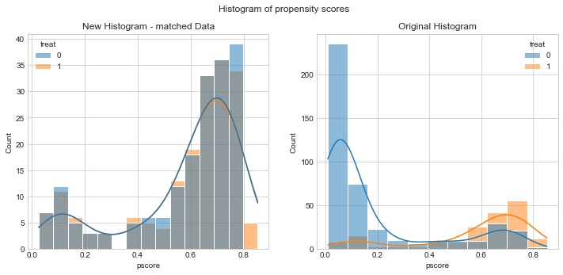

```python
fig, ax = plt.subplots(1,2, figsize=(12,5))

sns.histplot(data=pscore_df1, x='pscore', hue='treat', kde=True, ax=ax[0])
ax[0].set(title="New Histogram - matched Data")

sns.histplot(data=pscore_df, x='pscore', hue='treat', kde=True, ax=ax[1])
ax[1].set(title="Original Histogram")
plt.suptitle("Histogram of propensity scores");
```

```python
smdTable['SMD_MatchedDF'] = smdTable['features'].map(lambda x: round(SMD(matched_lalonde, 'treat', x)[0], 2) )
smdTable['Itr_MatchedDF'] = smdTable['features'].map(lambda x: SMD(matched_lalonde, 'treat', x)[1] )

smdTable
```

|  | features | SMD | Itr | SMD_MatchedDF | Itr_MatchedDF |
| --- | --- | --- | --- | --- | --- |
| 0 | age | -0.24 | Seriously imbalanced | 0.20 | Seriously imbalanced |
| 1 | educ | 0.04 | Balanced feature | -0.01 | Balanced feature |
| 2 | black | 1.67 | Seriously imbalanced | 0.01 | Balanced feature |
| 3 | hispan | -0.28 | Seriously imbalanced | -0.02 | Balanced feature |
| 4 | married | -0.72 | Seriously imbalanced | 0.16 | Not necessarily balanced feature |
| 5 | nodegree | 0.24 | Seriously imbalanced | 0.01 | Balanced feature |
| 6 | re74 | -0.60 | Seriously imbalanced | -0.05 | Balanced feature |
| 7 | re75 | -0.29 | Seriously imbalanced | 0.01 | Balanced feature |
| 8 | re78 | -0.08 | Balanced feature | 0.26 | Seriously imbalanced |

### Exercise 6 :

Assess covariate balance after the $k$-NN matching. For this, compute the absolute standardized differences in means in the covariates after matching,
$$\mathrm{ASMD_a}(x)=\frac{\bar{x}_{t,a}-{\bar{x}_{c,a}}}{\sqrt{\frac{s^{2}_{t,b} + s^{2}_{c,b}}{2}}},$$ where $\bar{x}_{t,a}$ and $\bar{x}_{c,a}$ are, respectively, the means of covariate $x$ in the treatment and control groups after matching, and $s^{2}_{t,b}$ and $s^{2}_{c,b}$ are, correspondingly, the sample variances treatment and control groups before matching.

One reason to use the sample variances before matching rather than the sample variances after matching is to free the comparisons of the means after matching from simultaneous changes in the variances. Comment on covariate balance.

**Answer.**

```python
def ASMD(df_original:pd.DataFrame, df_matched:pd.DataFrame, treatment:str, feature:str):
    try:
        tv1 = df_original[df_original[treatment] == 1][feature]
        cv1 = df_original[df_original[treatment] == 0][feature]
        tv2 = df_matched[df_matched[treatment] == 1][feature]
        cv2 = df_matched[df_matched[treatment] == 0][feature]
    except:
        print('Treatment variable should be coded as 0 or 1')
    asmd = (tv2.mean() - cv2.mean()) / ( np.sqrt(tv1.var() + cv1.var())/2 )
    # Interpretation
    if (np.abs(asmd) < 0.1):
        interpret = 'Balanced feature'
    elif (np.abs(asmd) <= 0.2):
        interpret = 'Not necessarily balanced feature'
    else:
        interpret = 'Seriously imbalanced'
    #
    return([asmd, interpret])
```

```python
smdTable['ASMD'] = smdTable['features'].map(lambda x: round(ASMD(lalonde_df, matched_lalonde, 'treat', x)[0], 2) )
smdTable['Itr_ASMD'] = smdTable['features'].map(lambda x: ASMD(lalonde_df, matched_lalonde, 'treat', x)[1] )

smdTable
```

|  | features | SMD | Itr | SMD_MatchedDF | Itr_MatchedDF | ASMD | Itr_ASMD |
| --- | --- | --- | --- | --- | --- | --- | --- |
| 0 | age | -0.24 | Seriously imbalanced | 0.20 | Seriously imbalanced | 0.26 | Seriously imbalanced |
| 1 | educ | 0.04 | Balanced feature | -0.01 | Balanced feature | -0.02 | Balanced feature |
| 2 | black | 1.67 | Seriously imbalanced | 0.01 | Balanced feature | 0.02 | Balanced feature |
| 3 | hispan | -0.28 | Seriously imbalanced | -0.02 | Balanced feature | -0.03 | Balanced feature |
| 4 | married | -0.72 | Seriously imbalanced | 0.16 | Not necessarily balanced feature | 0.19 | Not necessarily balanced feature |
| 5 | nodegree | 0.24 | Seriously imbalanced | 0.01 | Balanced feature | 0.02 | Balanced feature |
| 6 | re74 | -0.60 | Seriously imbalanced | -0.05 | Balanced feature | -0.06 | Balanced feature |
| 7 | re75 | -0.29 | Seriously imbalanced | 0.01 | Balanced feature | 0.01 | Balanced feature |
| 8 | re78 | -0.08 | Balanced feature | 0.26 | Seriously imbalanced | 0.33 | Seriously imbalanced |

### Exercise 7 :

Estimate the average effect of treatment on wages (`re78`) after matching. What do you conclude?

**Answer.**

```python
print('-'*40)
print('Effect Comparison on Mean of re78')
print('Original DataFrame: \t{:.2f}'.format(round(lalonde_df.query('treat==1').re78.mean() - lalonde_df.query('treat==0').re78.mean())))
print('Matched DataFrame: \t{:.2f}'.format(round( matched_lalonde.query('treat==1').re78.mean() - matched_lalonde.query('treat==0').re78.mean() )) )
print('-'*40)
```

```
----------------------------------------
Effect Comparison on Mean of re78
Original DataFrame: 	-635.00
Matched DataFrame: 	1774.00
----------------------------------------
```

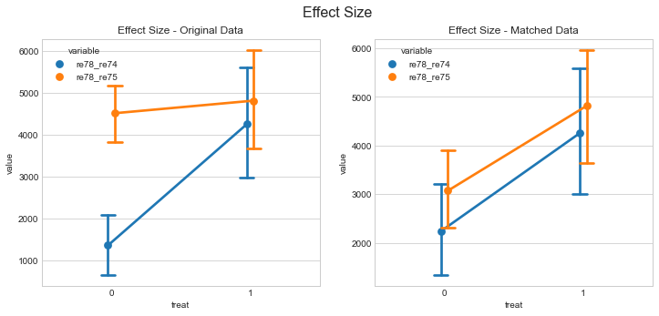

```python
def calculateEffect(df, keep):
    df['re78_re74'] = df['re78'] - df['re74']
    df['re78_re75'] = df['re78'] - df['re75']
    df = df.reset_index()
    return(pd.melt(df, id_vars=['index', keep], value_vars=['re78_re74', 're78_re75']))

fig, ax = plt.subplots(1,2, figsize=(12,5))
sns.pointplot(x='treat', y='value', hue='variable', dodge=True, capsize=.1,
              data = calculateEffect(lalonde_df, 'treat'), ax=ax[0])
ax[0].set(title="Effect Size - Original Data")
sns.pointplot(x='treat', y='value', hue='variable', ax=ax[1], dodge=True, capsize=.1,
              data = calculateEffect(matched_lalonde, 'treat'))
ax[1].set(title="Effect Size - Matched Data")
plt.suptitle("Effect Size", fontsize=16);
```

```python
from scipy import stats

def calculateTest(df: pd.DataFrame, var:str, criteria:str):
    a = df[df[criteria] == 1][var]
    b = df[df[criteria] == 0][var]

    diff = a.mean() - b.mean()
    lev, p_lev = stats.levene(np.array(a), np.array(b))

    if p_lev < 0.05:
        results = stats.ttest_ind(np.array(a), np.array(b), equal_var=False)
        varianz = 'Not Equal Variances'
    else:
        results = stats.ttest_ind(np.array(a), np.array(b), equal_var=True)
        varianz = 'Equal Variances'

    return {'Difference':diff, 'T':results[0], 'p_value':results[1], 'Varianz':varianz}

efectSizeTest = pd.DataFrame({
    'DataSet':['lalonde_df', 'lalonde_df', 'matched_lalonde', 'matched_lalonde'],
    'Variable':['re78_re74', 're78_re75', 're78_re74', 're78_re75']
})

efectSizeTest['Diff'] = efectSizeTest\
                    .apply(lambda x : calculateTest(eval(x['DataSet']), x['Variable'], 'treat')['Difference'], axis=1)
efectSizeTest['T'] = efectSizeTest\
                    .apply(lambda x : calculateTest(eval(x['DataSet']), x['Variable'], 'treat')['T'], axis=1)
efectSizeTest['pval'] = efectSizeTest\
                    .apply(lambda x : calculateTest(eval(x['DataSet']), x['Variable'], 'treat')['p_value'], axis=1)
efectSizeTest['Var'] = efectSizeTest\
                    .apply(lambda x : calculateTest(eval(x['DataSet']), x['Variable'], 'treat')['Varianz'], axis=1)

efectSizeTest
```

|  | DataSet | Variable | Diff | T | pval | Var |
| --- | --- | --- | --- | --- | --- | --- |
| 0 | lalonde_df | re78_re74 | 2888.636606 | 4.141601 | 0.000039 | Equal Variances |
| 1 | lalonde_df | re78_re75 | 299.402917 | 0.462987 | 0.643538 | Equal Variances |
| 2 | matched_lalonde | re78_re74 | 2015.350565 | 2.479115 | 0.013660 | Not Equal Variances |
| 3 | matched_lalonde | re78_re75 | 1746.335016 | 2.388545 | 0.017494 | Not Equal Variances |

## Propensity score matching using decision trees and random forests

### Exercise 8 :

To validate our propensity score calculations, let's try calculating them using other models such as decision trees and random forests.

#### 8.1

Build a decision tree regressor where the outcome variable is whether a subject was in the treatment group or not, and the covariates are all the other variables except `re78`. Use the `sklearn.tree` function `DecisionTreeRegressor(max_depth=4)` and call the new propensity scores `pscore_tree`.

**Answer.**

```python
pscore_tree = tree.DecisionTreeClassifier(max_depth = 4)
#
pscore_tree = pscore_tree.fit(lalonde_df_copy[covariates], lalonde_df_copy['treat'])
pscore_tree
```

```
DecisionTreeClassifier(max_depth=4)
```

#### 8.2

Plot the decision tree regressor using the code

```
fig = plt.gcf()
fig.set_size_inches(150, 100)
tree.plot_tree(dt,filled=True,feature_names=cleaned_df.columns)
fig.savefig('tree.png')
```

Replace `dt` with the name of the model created in Exercise 8.1. Use the plot to estimate the probability that a 24 year old, single, uneducated Hispanic individual that earned $\$20000$ in 1974 was enrolled in the employment program. Do the same with a black man with the same characteristics. (Assume that there were no black Hispanics in the study.)

**Answer.**

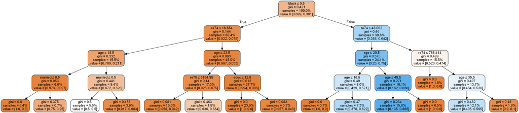

```python
dot_data = StringIO()

export_graphviz(pscore_tree, out_file=dot_data, feature_names = covariates,
#                 class_names=['treat'],
                filled=True, rounded=True,
                special_characters=True,
                impurity='gini', proportion=True)
graph = pydotplus.graph_from_dot_data(dot_data.getvalue())
# graph.write_png('tree.png')
Image(graph.create_png())
```

```python
# This plot has to much spacing and is not clearly readable
# fig = plt.gcf()
# fig.set_size_inches(150, 100)
# tree.plot_tree(pscore_tree,filled=True,feature_names=covariates)
# fig.savefig('tree.png');
```

```python
pscore_tree_pred = pscore_tree.predict_proba(lalonde_df_copy[covariates])
```

#### 8.3

Estimate the propensity scores now by using random forests. For the model, use the `sklearn.ensemble` function `RandomForestClassifier` with parameters `n_estimators=100, max_depth=4, random_state=42`. Then, use the method `predict_proba` to extract the propensity scores. Name the scores `pscore_forest`.

**Answer.**

```python
pscore_forest = ensemble.RandomForestClassifier(n_estimators=100, max_depth=4, random_state=42)
#
pscore_forest = pscore_forest.fit(lalonde_df_copy[covariates], lalonde_df_copy['treat'])
pscore_forest
```

```
RandomForestClassifier(max_depth=4, random_state=42)
```

```python
pscore_forest_pred = pscore_forest.predict_proba(lalonde_df_copy[covariates])
```

```python
covariates_categorical = [i for i in covariates if i not in ['age', 'educ', 're74', 're75']]
covariates_continous = [i for i in covariates if i in ['age', 'educ', 're74', 're75']]

pscore_gnb_categorical = MultinomialNB()
pscore_gnb_categorical = pscore_gnb_categorical.fit(lalonde_df_copy[covariates_categorical], lalonde_df_copy['treat'])

pscore_gnb_continous = GaussianNB()
pscore_gnb_continous = pscore_gnb_continous.fit(lalonde_df_copy[covariates_continous], lalonde_df_copy['treat'])

# Prediction
def marginalProb(df:pd.DataFrame, crit:str, val):
    cases = df[df[crit]==val][crit].count()
    total = df[crit].count()
    p = cases/total; return p

pscore_gnb_categorical_pred = (pscore_gnb_categorical
                               .predict_proba(lalonde_df_copy[covariates_categorical]))
pscore_gnb_continous_pred = (pscore_gnb_continous
                             .predict_proba(lalonde_df_copy[covariates_continous]))

pscore_gnb_pred = np.multiply(pscore_gnb_categorical_pred, pscore_gnb_continous_pred)/np.array([p_treat_1, 1-p_treat_1])
```

#### 8.4

Make a plot with the three ROC curves corresponding to the logistic regression, decision tree, and random forest classifiers used to compute the propensity scores. What is the AUC of each model? Which model *seems* to do the best job?

**Answer.**

```python
roc_logis = metrics.roc_curve(lalonde_df_copy['treat'], pscore_logit)
roc_tree = metrics.roc_curve(lalonde_df_copy['treat'], pscore_tree_pred[:,1] )
roc_forest = metrics.roc_curve(lalonde_df_copy['treat'], pscore_forest_pred[:,1] )
roc_nbc = metrics.roc_curve(lalonde_df_copy['treat'], pscore_gnb_pred[:,1] )
```

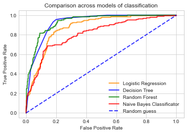

```python
plt.plot(roc_logis[0], roc_logis[1], color='darkorange', lw=2, alpha=.8,
         label=f"Logistic Regression")
plt.plot(roc_tree[0], roc_tree[1], color='blue', lw=2, alpha=.8,
         label=f"Decision Tree")
plt.plot(roc_forest[0], roc_forest[1], color='green', lw=2, alpha=.8,
         label=f"Random Forest")
plt.plot(roc_nbc[0], roc_nbc[1], color='red', lw=2, alpha=.8,
         label=f"Naive Bayes Classificator")
plt.plot([0, 1], [0, 1], linestyle='--', lw=2, color='blue', label='Random guess', alpha=.8)

plt.xlabel('False Positive Rate')
plt.ylabel('True Positive Rate')
plt.legend(loc='lower right')
plt.title('Comparison across models of classification')
plt.show();
```

```python
AUC_summary = pd.DataFrame({
    'Model': ['Logistic Reg.', 'Decision Tree', 'Random Forest', 'Naive Bayes Classificator'],
    'AUC': [metrics.auc(roc_logis[0], roc_logis[1]),
            metrics.auc(roc_tree[0], roc_tree[1]),
            metrics.auc(roc_forest[0], roc_forest[1]),
            metrics.auc(roc_nbc[0], roc_nbc[1])]
})
AUC_summary
```

|  | Model | AUC |
| --- | --- | --- |
| 0 | Logistic Reg. | 0.874227 |
| 1 | Decision Tree | 0.926038 |
| 2 | Random Forest | 0.932521 |
| 3 | Naive Bayes Classificator | 0.812008 |

#### 8.5

Consider the following statement:

> "*A model with a higher AUC provides much better estimates of the true propensity scores. In particular, a matching using the propensity scores of such a model will balance the covariates much better.*"

Is the statement true or false? Explain.

**Answer.**

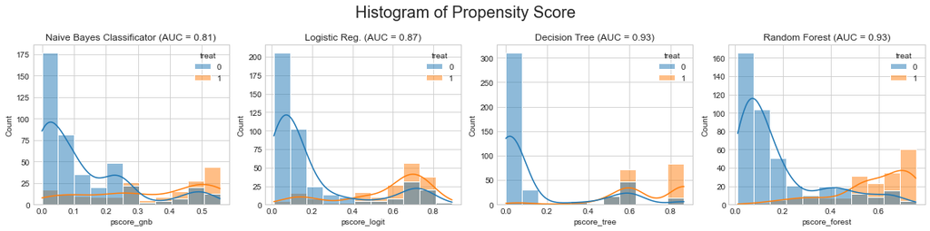

```python
pscore_logit = lo_mod_Full.predict()
pscore_df = pd.DataFrame({'treat':lalonde_df_copy['treat'],
                          'pscore_logit':pscore_logit,
                          'pscore_tree':pscore_tree_pred[:,1],
                          'pscore_forest':pscore_forest_pred[:,1],
                          'pscore_gnb':pscore_gnb_pred[:,1]
                         })


fig, ax = plt.subplots(1,4, figsize=(16,4) )
sns.histplot(data=pscore_df, x='pscore_gnb', hue='treat', kde=True, ax=ax[0])
sns.histplot(data=pscore_df, x='pscore_logit', hue='treat', kde=True, ax=ax[1])
sns.histplot(data=pscore_df, x='pscore_tree', hue='treat', kde=True, ax=ax[2])
sns.histplot(data=pscore_df, x='pscore_forest', hue='treat', kde=True, ax=ax[3])
for i,pos in enumerate([1,2,3,0]):
    ax[pos].set(title = '{model} (AUC = {auc:.2f})'.format(model=AUC_summary.loc[i,'Model'],
                                                           auc=AUC_summary.loc[i,'AUC']))

plt.suptitle("Histogram of Propensity Score", fontsize=20)
fig.set_tight_layout(True);
```

#### 8.6

Repeat the matching procedure now with the estimated propensity scores `pscore_tree` and `pscore_forest`. Assess the covariate balances and estimate the average effect of treatment on wages (`re78`) after matching. Compare your results.

**Answer.**

```python
def createMatchedDataframe(df:pd.DataFrame, crit:str, predictions:np.array, n_neighbors=5, metric='euclidean'):
    # Append column of predicctions to DataFrame
    df['pscore'] = predictions
    # Select positive and negative pscores
    treat_pscores   = df[df[crit]==1]['pscore']
    control_pscores = df[df[crit]==0]['pscore']
    # Set engine and fit Nearest Neighbors with Control Values
    neigh = NearestNeighbors(n_neighbors = n_neighbors, metric = metric)
    neigh.fit(control_pscores.values.reshape(-1,1))
    # Create a list with main k nearest values to treatment arm and find most similar cases in control arm
    listSimilars = []
    listDist = []
    for i, sample in enumerate(treat_pscores):
        dist, arr = neigh.kneighbors([[sample]], n_neighbors, return_distance=True)
        similars = control_pscores.iloc[arr[0]]
        listSimilars.append(similars)
        listDist.append(dist)
    # Create a new Data Frame with characteristic of nearest values on control arm to treatment arm
    match_df = pd.DataFrame()
    for i, sims in enumerate(listSimilars):
        matched_id = sims.index[0]
        row = df[df.index == matched_id]
        match_df = pd.concat([match_df, row])
    # Concatenate both DataFrames
    match_df_T = pd.concat([df[df[crit]==1], match_df])

    return {'DataFrame' : match_df_T, 'listSimilars':listSimilars, 'match_df':match_df, 'Distances':listDist}
```

```python
match_lalonde_logis  = createMatchedDataframe(lalonde_df, 'treat', pscore_logit)['DataFrame']
match_lalonde_tree   = createMatchedDataframe(lalonde_df, 'treat', pscore_tree_pred[:,1])['DataFrame']
match_lalonde_forest = createMatchedDataframe(lalonde_df, 'treat', pscore_forest_pred[:,1])['DataFrame']
match_lalonde_gnb    = createMatchedDataframe(lalonde_df, 'treat', pscore_gnb_pred[:,1])['DataFrame']
```

```python
smdTable = pd.DataFrame({'features':["age", "educ", "black", "hispan", "married", "nodegree", "re74", "re75", "re78"]})
smdTable['GNB-ASMD']     = smdTable['features'].map(lambda x: round(ASMD(lalonde_df, match_lalonde_gnb, 'treat', x)[0], 2) )
smdTable['GNB-Itr_ASMD'] = smdTable['features'].map(lambda x: ASMD(lalonde_df, match_lalonde_gnb, 'treat', x)[1] )
#
smdTable['Logis-ASMD']     = smdTable['features'].map(lambda x: round(ASMD(lalonde_df, match_lalonde_logis, 'treat', x)[0], 2) )
smdTable['Logis-Itr_ASMD'] = smdTable['features'].map(lambda x: ASMD(lalonde_df, match_lalonde_logis, 'treat', x)[1] )
#
smdTable['Tree-ASMD']     = smdTable['features'].map(lambda x: round(ASMD(lalonde_df, match_lalonde_tree, 'treat', x)[0], 2) )
smdTable['Tree-Itr_ASMD'] = smdTable['features'].map(lambda x: ASMD(lalonde_df, match_lalonde_tree, 'treat', x)[1] )
#
smdTable['Forest-ASMD']     = smdTable['features'].map(lambda x: round(ASMD(lalonde_df, match_lalonde_forest, 'treat', x)[0], 2) )
smdTable['Forest-Itr_ASMD'] = smdTable['features'].map(lambda x: ASMD(lalonde_df, match_lalonde_forest, 'treat', x)[1] )
#
smdTable
```

[output not shown]

#### 8.7

Why do you think the decision tree regressor performed badly on balancing the covariates of the treat and control groups?

**Hint:** Look at the distances of the ten nearest neighbors output by `.kneighbors()` for the propensity scores of the decision tree model. What do you see? Why do you think these distances may have an impact on balancing?

**Answer.**

```python
def getValuesforScore(scoreArray:np.array, n_neighbors=5):
    dummy = createMatchedDataframe(lalonde_df, 'treat', scoreArray, n_neighbors=n_neighbors)['Distances']
    kvec = ['k'+str(i+1) for i in range(n_neighbors)]
    list_Dict = []
    for i, var in enumerate(dummy):
        new_dic = {}
        for j in range(n_neighbors):
            new_dic[kvec[j]] = var[0][j]
        list_Dict.append(new_dic)
    df = pd.DataFrame(list_Dict)
    df = pd.melt(df)
    return(df)
```

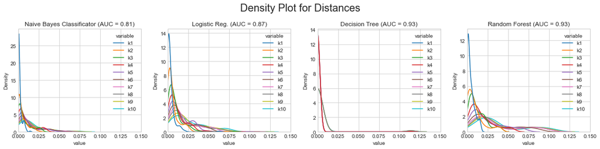

```python
fig, ax = plt.subplots(1,4, figsize=(16,4), sharex=True )

sns.kdeplot(data=getValuesforScore( pscore_gnb_pred[:,1],10 ),
             x='value', hue='variable', ax=ax[0]);

sns.kdeplot(data=getValuesforScore( pscore_logit,10 ),
             x='value', hue='variable', ax=ax[1]);

sns.kdeplot(data=getValuesforScore( pscore_tree_pred[:,1],10 ),
             x='value', hue='variable', ax=ax[2]);

sns.kdeplot(data=getValuesforScore( pscore_forest_pred[:,1],10 ),
             x='value', hue='variable', ax=ax[3]);

for i,pos in enumerate([1,2,3,0]):
    ax[pos].set(title = '{model} (AUC = {auc:.2f})'.format(model=AUC_summary.loc[i,'Model'],
                                                           auc=AUC_summary.loc[i,'AUC']),
               xlim=(0.00, 0.15))

plt.suptitle("Density Plot for Distances", fontsize=20)
fig.set_tight_layout(True);
```

If we look at the graph for the decision tree we see that the density of distances for the k10 nearest neighbors is very similar. This is clearly presented because a tree is a discrete structure, and this when performing the classification only generates a discrete amount of possible probability values. This unlike the rest of algorithms, for this reason it can choose neighbors that have no important relationship as they are not necessarily related.